# Variable Selection Methods

## All Possible Regression

All subset regression tests all possible subsets of the set of potential independent variables. If there are K potential independent variables (besides the constant), then there are $2^{k}$ distinct subsets of them to be tested. For example, if you have 10 candidate independent variables, the number of subsets to be tested is $2^{10}$, which is 1024, and if you have 20 candidate variables, the number is $2^{20}$, which is more than one million.

```r
model <- lm(mpg ~ disp + hp + wt + qsec, data = mtcars)
ols_step_all_possible(model)
```

```
##    Index N      Predictors  R-Square Adj. R-Square Mallow's Cp
## 3      1 1              wt 0.7528328     0.7445939   12.480939
## 1      2 1            disp 0.7183433     0.7089548   18.129607
## 2      3 1              hp 0.6024373     0.5891853   37.112642
## 4      4 1            qsec 0.1752963     0.1478062  107.069616
## 8      5 2           hp wt 0.8267855     0.8148396    2.369005
## 10     6 2         wt qsec 0.8264161     0.8144448    2.429492
## 6      7 2         disp wt 0.7809306     0.7658223    9.879096
## 5      8 2         disp hp 0.7482402     0.7308774   15.233115
## 7      9 2       disp qsec 0.7215598     0.7023571   19.602810
## 9     10 2         hp qsec 0.6368769     0.6118339   33.472150
## 14    11 3      hp wt qsec 0.8347678     0.8170643    3.061665
## 11    12 3      disp hp wt 0.8268361     0.8082829    4.360702
## 13    13 3    disp wt qsec 0.8264170     0.8078189    4.429343
## 12    14 3    disp hp qsec 0.7541953     0.7278591   16.257790
## 15    15 4 disp hp wt qsec 0.8351443     0.8107212    5.000000
```

The `plot` method shows the panel of fit criteria for all possible regression methods.

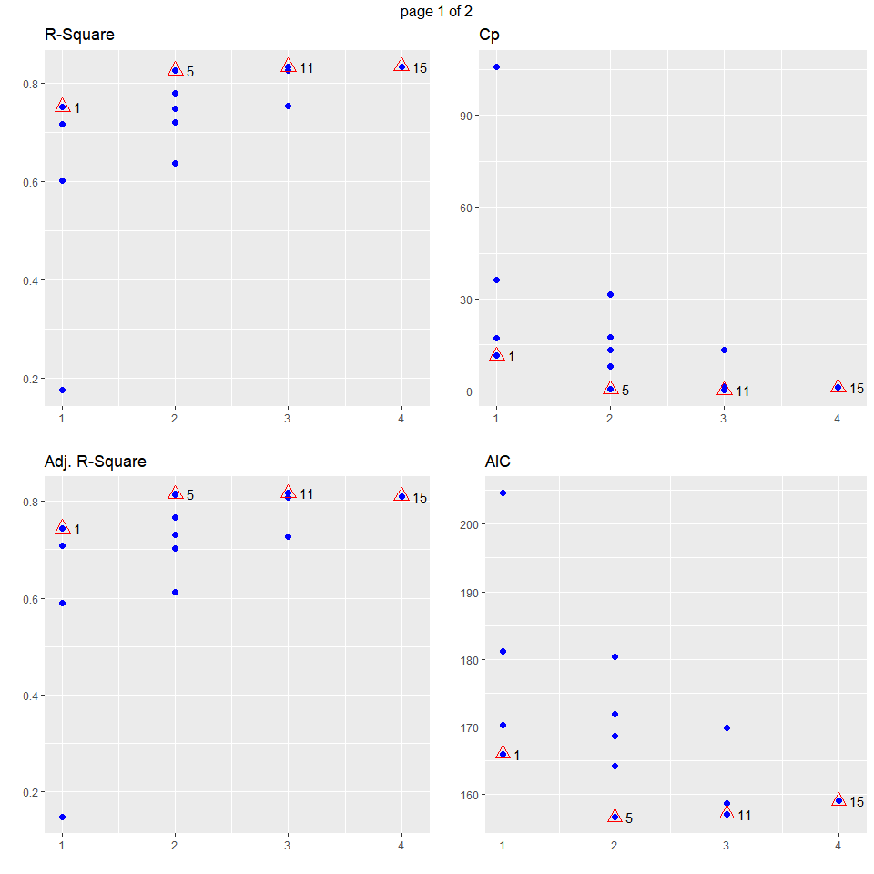

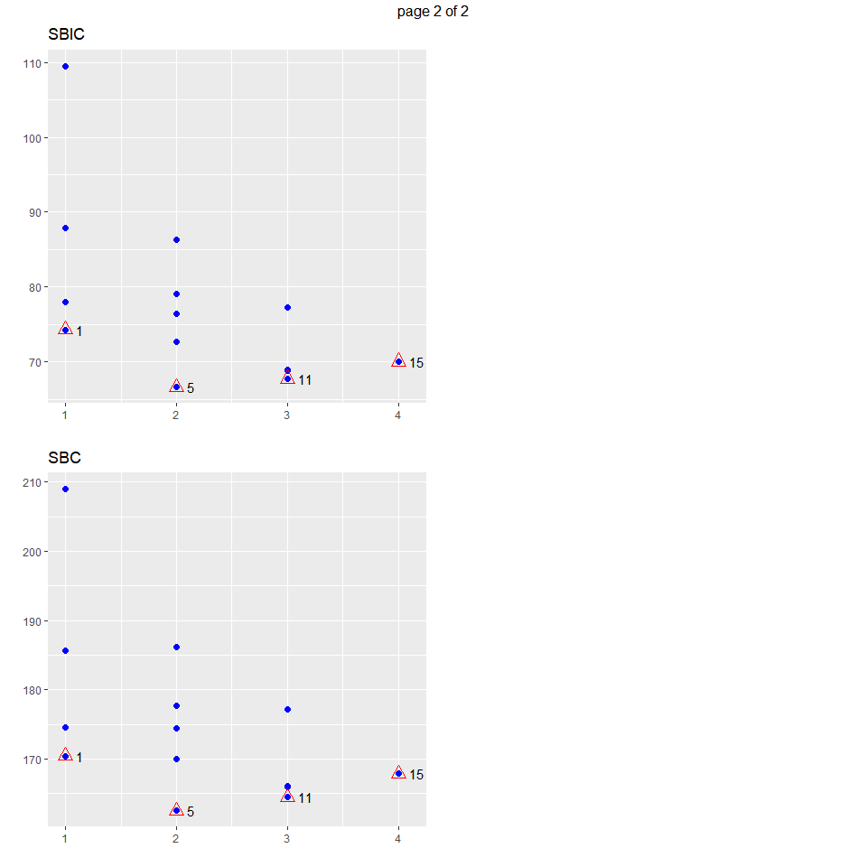

```r
model <- lm(mpg ~ disp + hp + wt + qsec, data = mtcars)
k <- ols_step_all_possible(model)
plot(k)
```

## Best Subset Regression

Select the subset of predictors that do the best at meeting some well-defined objective criterion, such as having the largest R2 value or the smallest MSE, Mallow’s Cp or AIC.

```r
model <- lm(mpg ~ disp + hp + wt + qsec, data = mtcars)
ols_step_best_subset(model)
```

```
##    Best Subsets Regression
## ------------------------------
## Model Index    Predictors
## ------------------------------
##      1         wt
##      2         hp wt
##      3         hp wt qsec
##      4         disp hp wt qsec
## ------------------------------
##
##                                                    Subsets Regression Summary
## ---------------------------------------------------------------------------------------------------------------------------------
##                        Adj.        Pred
## Model    R-Square    R-Square    R-Square     C(p)        AIC        SBIC        SBC         MSEP       FPE       HSP       APC
## ---------------------------------------------------------------------------------------------------------------------------------
##   1        0.7528      0.7446      0.7087    12.4809    166.0294    74.2916    170.4266    296.9167    9.8572    0.3199    0.2801
##   2        0.8268      0.8148      0.7811     2.3690    156.6523    66.5755    162.5153    215.5104    7.3563    0.2402    0.2091
##   3        0.8348      0.8171       0.782     3.0617    157.1426    67.7238    164.4713    213.1929    7.4756    0.2461    0.2124
##   4        0.8351      0.8107       0.771     5.0000    159.0696    70.0408    167.8640    220.8882    7.9497    0.2644    0.2259
## ---------------------------------------------------------------------------------------------------------------------------------
## AIC: Akaike Information Criteria
##  SBIC: Sawa's Bayesian Information Criteria
##  SBC: Schwarz Bayesian Criteria
##  MSEP: Estimated error of prediction, assuming multivariate normality
##  FPE: Final Prediction Error
##  HSP: Hocking's Sp
##  APC: Amemiya Prediction Criteria
```

The `plot` method shows the panel of fit criteria for best subset regression methods.

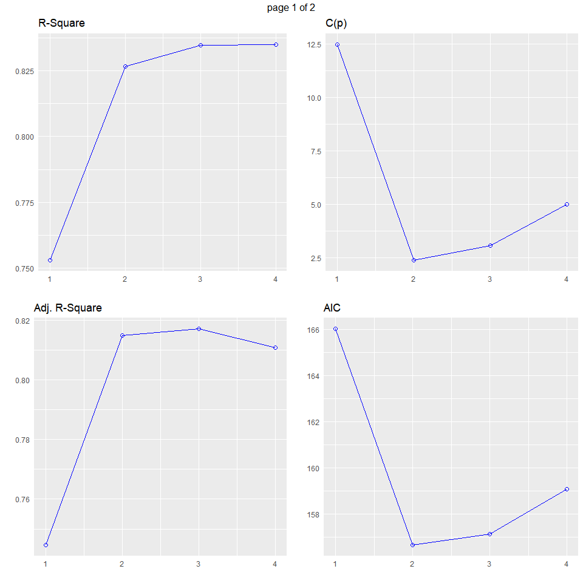

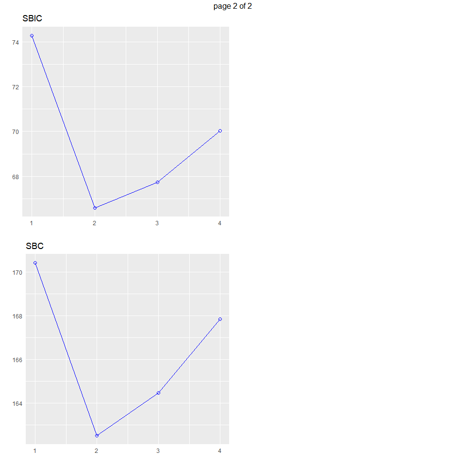

```r
model <- lm(mpg ~ disp + hp + wt + qsec, data = mtcars)
k <- ols_step_best_subset(model)
plot(k)
```

## Stepwise Forward Regression

Build regression model from a set of candidate predictor variables by entering predictors based on p values, in a stepwise manner until there is no variable left to enter any more. The model should include all the candidate predictor variables. If details is set to `TRUE`, each step is displayed.

### Variable Selection

```r
# stepwise forward regression
model <- lm(y ~ ., data = surgical)
ols_step_forward_p(model)
```

```
##
##                               Selection Summary
## ------------------------------------------------------------------------------
##         Variable                     Adj.
## Step      Entered      R-Square    R-Square     C(p)        AIC         RMSE
## ------------------------------------------------------------------------------
##    1    liver_test       0.4545      0.4440    62.5119    771.8753    296.2992
##    2    alc_heavy        0.5667      0.5498    41.3681    761.4394    266.6484
##    3    enzyme_test      0.6590      0.6385    24.3379    750.5089    238.9145
##    4    pindex           0.7501      0.7297     7.5373    735.7146    206.5835
##    5    bcs              0.7809      0.7581     3.1925    730.6204    195.4544
## ------------------------------------------------------------------------------
```

### Plot

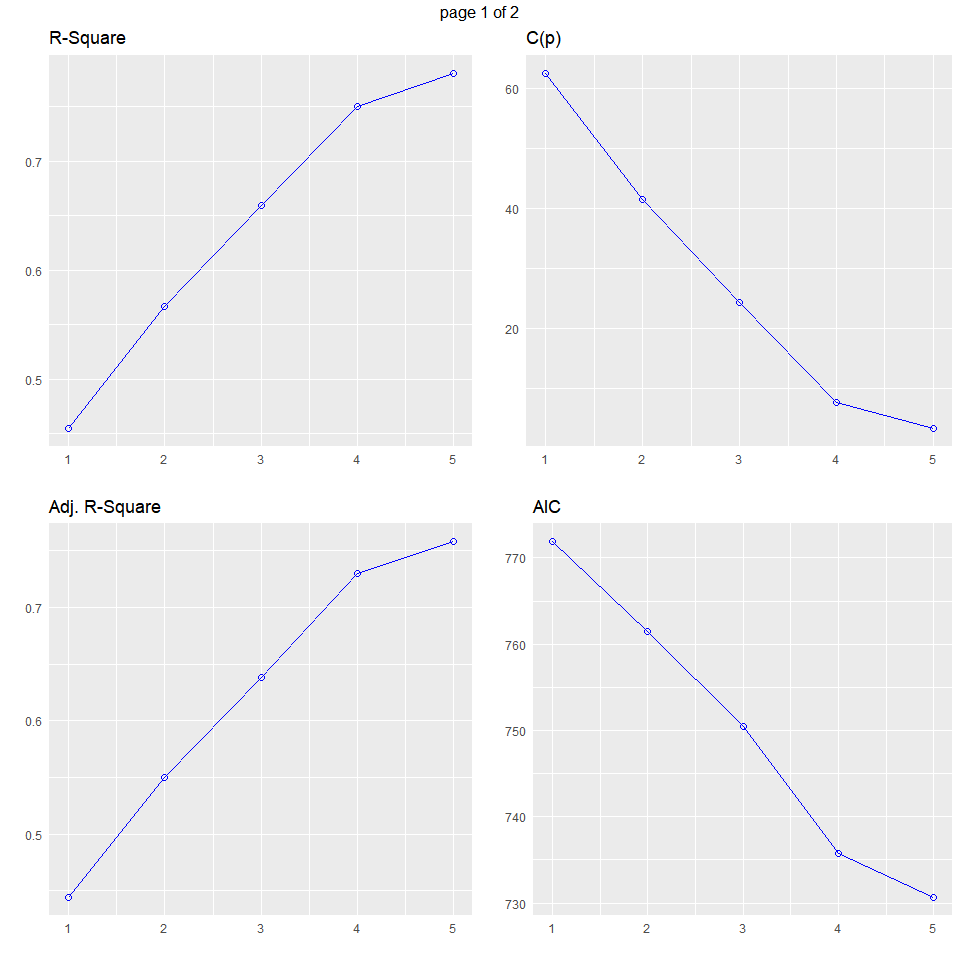

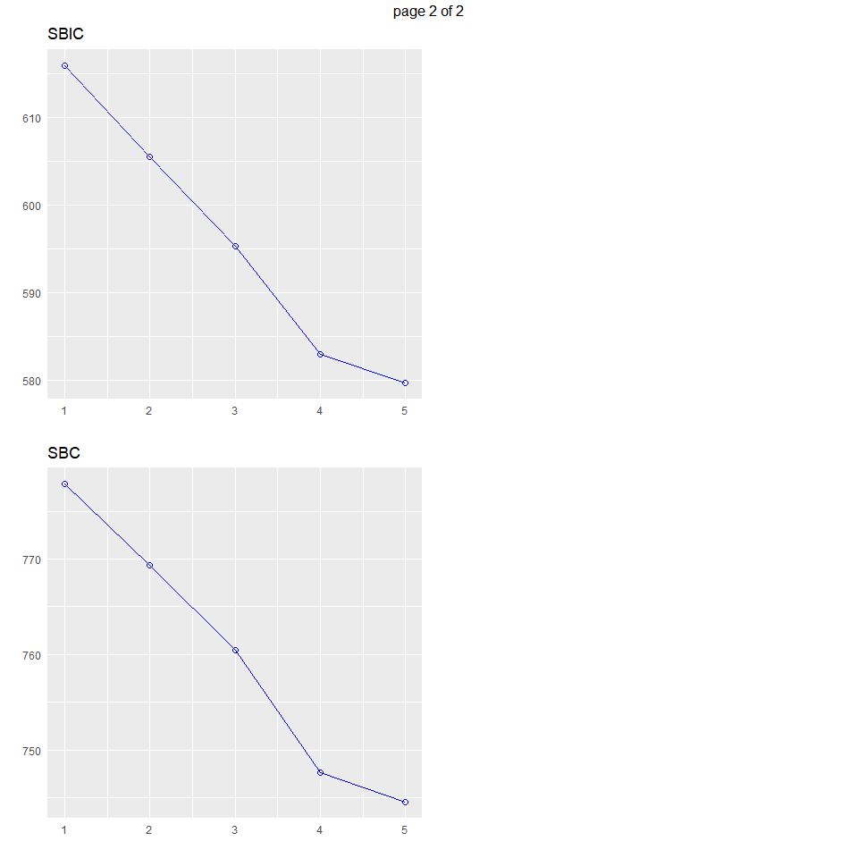

```r
model <- lm(y ~ ., data = surgical)
k <- ols_step_forward_p(model)
plot(k)
```

### Detailed Output

```r
# stepwise forward regression
model <- lm(y ~ ., data = surgical)
ols_step_forward_p(model, details = TRUE)
```

```
## Forward Selection Method
## ---------------------------
##
## Candidate Terms:
##
## 1. bcs
## 2. pindex
## 3. enzyme_test
## 4. liver_test
## 5. age
## 6. gender
## 7. alc_mod
## 8. alc_heavy
##
## We are selecting variables based on p value...
##
##
## Forward Selection: Step 1
##
## - liver_test
##
##                           Model Summary
## -----------------------------------------------------------------
## R                       0.674       RMSE                 296.299
## R-Squared               0.455       Coef. Var             42.202
## Adj. R-Squared          0.444       MSE                87793.232
## Pred R-Squared          0.386       MAE                  212.857
## -----------------------------------------------------------------
##  RMSE: Root Mean Square Error
##  MSE: Mean Square Error
##  MAE: Mean Absolute Error
##
##                                  ANOVA
## -----------------------------------------------------------------------
##                    Sum of
##                   Squares        DF    Mean Square      F         Sig.
## -----------------------------------------------------------------------
## Regression    3804272.477         1    3804272.477    43.332    0.0000
## Residual      4565248.060        52      87793.232
## Total         8369520.537        53
```

[output cut: 193 more lines]

```
## Residual      1833716.447        48      38202.426
## Total         8369520.537        53
## -----------------------------------------------------------------------
##
##                                       Parameter Estimates
## ------------------------------------------------------------------------------------------------
##       model         Beta    Std. Error    Std. Beta      t        Sig         lower       upper
## ------------------------------------------------------------------------------------------------
## (Intercept)    -1178.330       208.682                 -5.647    0.000    -1597.914    -758.746
##  liver_test       58.064        40.144        0.156     1.446    0.155      -22.652     138.779
##   alc_heavy      317.848        71.634        0.314     4.437    0.000      173.818     461.878
## enzyme_test        9.748         1.656        0.521     5.887    0.000        6.419      13.077
##      pindex        8.924         1.808        0.380     4.935    0.000        5.288      12.559
##         bcs       59.864        23.060        0.241     2.596    0.012       13.498     106.230
## ------------------------------------------------------------------------------------------------
```

```
##
##                               Selection Summary
## ------------------------------------------------------------------------------
##         Variable                     Adj.
## Step      Entered      R-Square    R-Square     C(p)        AIC         RMSE
## ------------------------------------------------------------------------------
##    1    liver_test       0.4545      0.4440    62.5119    771.8753    296.2992
##    2    alc_heavy        0.5667      0.5498    41.3681    761.4394    266.6484
##    3    enzyme_test      0.6590      0.6385    24.3379    750.5089    238.9145
##    4    pindex           0.7501      0.7297     7.5373    735.7146    206.5835
##    5    bcs              0.7809      0.7581     3.1925    730.6204    195.4544
## ------------------------------------------------------------------------------
```

## Stepwise Backward Regression

Build regression model from a set of candidate predictor variables by removing predictors based on p values, in a stepwise manner until there is no variable left to remove any more. The model should include all the candidate predictor variables. If details is set to `TRUE`, each step is displayed.

### Variable Selection

```r
# stepwise backward regression
model <- lm(y ~ ., data = surgical)
ols_step_backward_p(model)
```

```
##
##
##                            Elimination Summary
## --------------------------------------------------------------------------
##         Variable                  Adj.
## Step    Removed     R-Square    R-Square     C(p)       AIC         RMSE
## --------------------------------------------------------------------------
##    1    alc_mod       0.7818      0.7486    7.0141    734.4068    199.2637
##    2    gender        0.7814      0.7535    5.0870    732.4942    197.2921
##    3    age           0.7809      0.7581    3.1925    730.6204    195.4544
## --------------------------------------------------------------------------
```

### Plot

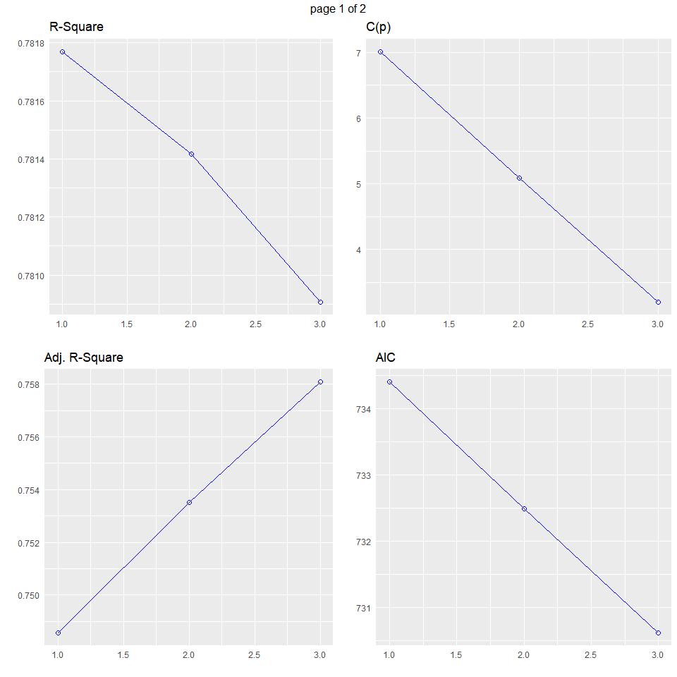

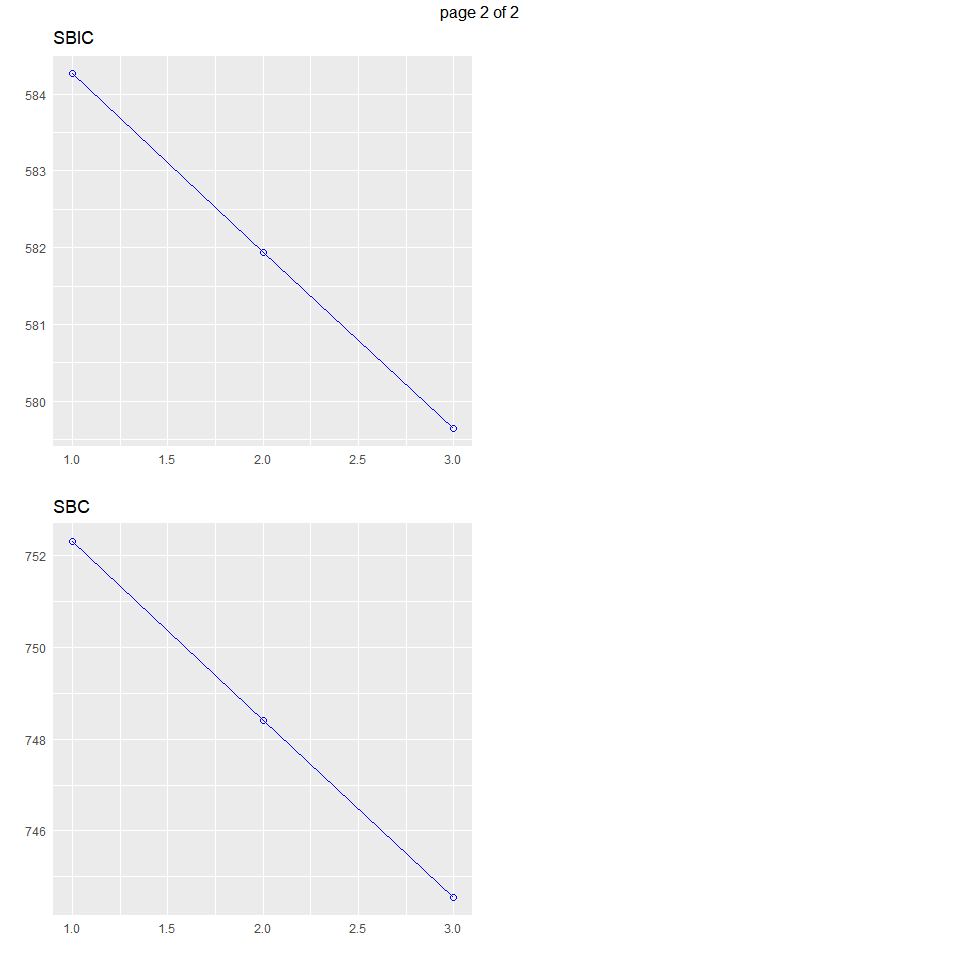

```r
model <- lm(y ~ ., data = surgical)
k <- ols_step_backward_p(model)
plot(k)
```

### Detailed Output

```r
# stepwise backward regression
model <- lm(y ~ ., data = surgical)
ols_step_backward_p(model, details = TRUE)
```

```
## Backward Elimination Method
## ---------------------------
##
## Candidate Terms:
##
## 1 . bcs
## 2 . pindex
## 3 . enzyme_test
## 4 . liver_test
## 5 . age
## 6 . gender
## 7 . alc_mod
## 8 . alc_heavy
##
## We are eliminating variables based on p value...
##
## - alc_mod
##
## Backward Elimination: Step 1
##
##  Variable alc_mod Removed
##
##                           Model Summary
## -----------------------------------------------------------------
## R                       0.884       RMSE                 199.264
## R-Squared               0.782       Coef. Var             28.381
## Adj. R-Squared          0.749       MSE                39706.040
## Pred R-Squared          0.678       MAE                  137.053
## -----------------------------------------------------------------
##  RMSE: Root Mean Square Error
##  MSE: Mean Square Error
##  MAE: Mean Absolute Error
##
##                                  ANOVA
## -----------------------------------------------------------------------
##                    Sum of
##                   Squares        DF    Mean Square      F         Sig.
## -----------------------------------------------------------------------
## Regression    6543042.709         7     934720.387    23.541    0.0000
## Residual      1826477.828        46      39706.040
```

[output cut: 130 more lines]

```
## Residual      1833716.447        48      38202.426
## Total         8369520.537        53
## -----------------------------------------------------------------------
##
##                                       Parameter Estimates
## ------------------------------------------------------------------------------------------------
##       model         Beta    Std. Error    Std. Beta      t        Sig         lower       upper
## ------------------------------------------------------------------------------------------------
## (Intercept)    -1178.330       208.682                 -5.647    0.000    -1597.914    -758.746
##         bcs       59.864        23.060        0.241     2.596    0.012       13.498     106.230
##      pindex        8.924         1.808        0.380     4.935    0.000        5.288      12.559
## enzyme_test        9.748         1.656        0.521     5.887    0.000        6.419      13.077
##  liver_test       58.064        40.144        0.156     1.446    0.155      -22.652     138.779
##   alc_heavy      317.848        71.634        0.314     4.437    0.000      173.818     461.878
## ------------------------------------------------------------------------------------------------
```

```
##
##
##                            Elimination Summary
## --------------------------------------------------------------------------
##         Variable                  Adj.
## Step    Removed     R-Square    R-Square     C(p)       AIC         RMSE
## --------------------------------------------------------------------------
##    1    alc_mod       0.7818      0.7486    7.0141    734.4068    199.2637
##    2    gender        0.7814      0.7535    5.0870    732.4942    197.2921
##    3    age           0.7809      0.7581    3.1925    730.6204    195.4544
## --------------------------------------------------------------------------
```

## Stepwise Regression

Build regression model from a set of candidate predictor variables by entering and removing predictors based on p values, in a stepwise manner until there is no variable left to enter or remove any more. The model should include all the candidate predictor variables. If details is set to `TRUE`, each step is displayed.

### Variable Selection

```r
# stepwise regression
model <- lm(y ~ ., data = surgical)
ols_step_both_p(model)
```

```
##
##                                 Stepwise Selection Summary
## ------------------------------------------------------------------------------------------
##                         Added/                   Adj.
## Step     Variable      Removed     R-Square    R-Square     C(p)        AIC         RMSE
## ------------------------------------------------------------------------------------------
##    1    liver_test     addition       0.455       0.444    62.5120    771.8753    296.2992
##    2     alc_heavy     addition       0.567       0.550    41.3680    761.4394    266.6484
##    3    enzyme_test    addition       0.659       0.639    24.3380    750.5089    238.9145
##    4      pindex       addition       0.750       0.730     7.5370    735.7146    206.5835
##    5        bcs        addition       0.781       0.758     3.1920    730.6204    195.4544
## ------------------------------------------------------------------------------------------
```

### Plot

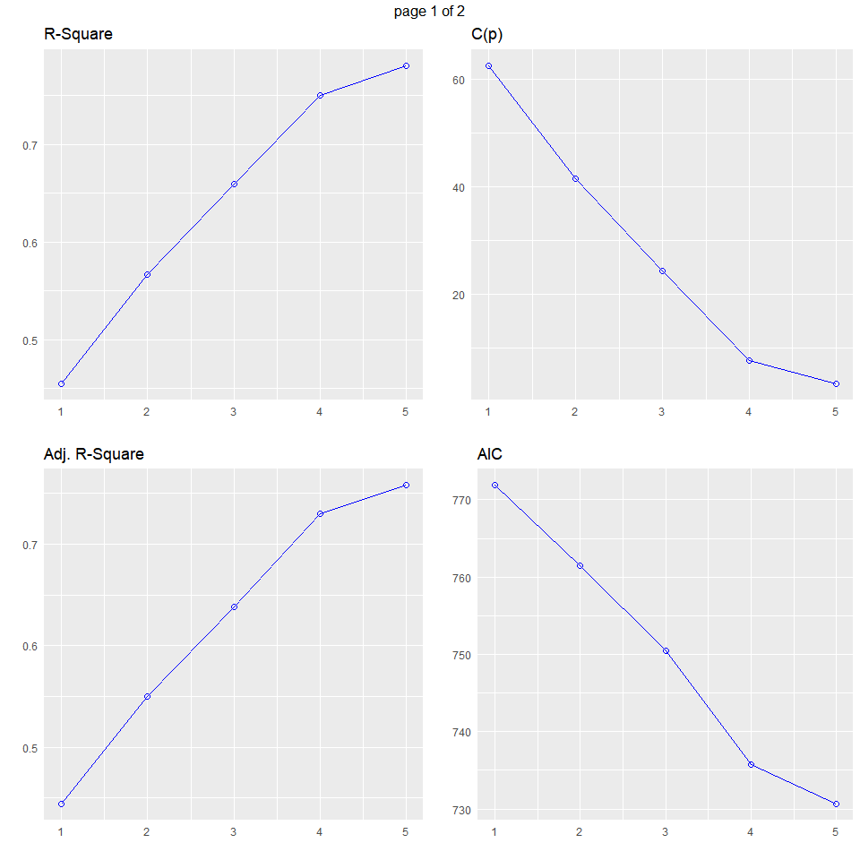

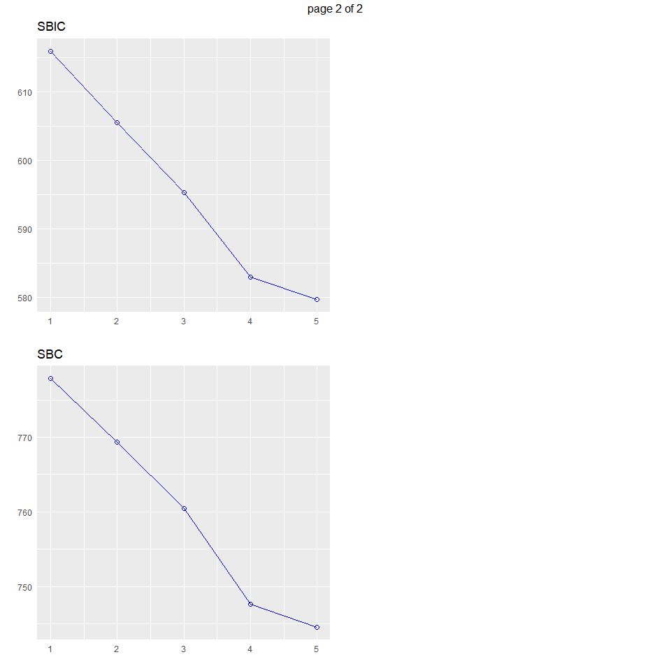

```r
model <- lm(y ~ ., data = surgical)
k <- ols_step_both_p(model)
plot(k)
```

### Detailed Output

```r
# stepwise regression
model <- lm(y ~ ., data = surgical)
ols_step_both_p(model, details = TRUE)
```

```
## Stepwise Selection Method
## ---------------------------
##
## Candidate Terms:
##
## 1. bcs
## 2. pindex
## 3. enzyme_test
## 4. liver_test
## 5. age
## 6. gender
## 7. alc_mod
## 8. alc_heavy
##
## We are selecting variables based on p value...
##
##
## Stepwise Selection: Step 1
##
## - liver_test added
##
##                           Model Summary
## -----------------------------------------------------------------
## R                       0.674       RMSE                 296.299
## R-Squared               0.455       Coef. Var             42.202
## Adj. R-Squared          0.444       MSE                87793.232
## Pred R-Squared          0.386       MAE                  212.857
## -----------------------------------------------------------------
##  RMSE: Root Mean Square Error
##  MSE: Mean Square Error
##  MAE: Mean Absolute Error
##
##                                  ANOVA
## -----------------------------------------------------------------------
##                    Sum of
##                   Squares        DF    Mean Square      F         Sig.
## -----------------------------------------------------------------------
## Regression    3804272.477         1    3804272.477    43.332    0.0000
## Residual      4565248.060        52      87793.232
## Total         8369520.537        53
```

[output cut: 319 more lines]

```
## Residual      1833716.447        48      38202.426
## Total         8369520.537        53
## -----------------------------------------------------------------------
##
##                                       Parameter Estimates
## ------------------------------------------------------------------------------------------------
##       model         Beta    Std. Error    Std. Beta      t        Sig         lower       upper
## ------------------------------------------------------------------------------------------------
## (Intercept)    -1178.330       208.682                 -5.647    0.000    -1597.914    -758.746
##  liver_test       58.064        40.144        0.156     1.446    0.155      -22.652     138.779
##   alc_heavy      317.848        71.634        0.314     4.437    0.000      173.818     461.878
## enzyme_test        9.748         1.656        0.521     5.887    0.000        6.419      13.077
##      pindex        8.924         1.808        0.380     4.935    0.000        5.288      12.559
##         bcs       59.864        23.060        0.241     2.596    0.012       13.498     106.230
## ------------------------------------------------------------------------------------------------
```

```
##
##                                 Stepwise Selection Summary
## ------------------------------------------------------------------------------------------
##                         Added/                   Adj.
## Step     Variable      Removed     R-Square    R-Square     C(p)        AIC         RMSE
## ------------------------------------------------------------------------------------------
##    1    liver_test     addition       0.455       0.444    62.5120    771.8753    296.2992
##    2     alc_heavy     addition       0.567       0.550    41.3680    761.4394    266.6484
##    3    enzyme_test    addition       0.659       0.639    24.3380    750.5089    238.9145
##    4      pindex       addition       0.750       0.730     7.5370    735.7146    206.5835
##    5        bcs        addition       0.781       0.758     3.1920    730.6204    195.4544
## ------------------------------------------------------------------------------------------
```

## Stepwise AIC Forward Regression

Build regression model from a set of candidate predictor variables by entering predictors based on Akaike Information Criteria, in a stepwise manner until there is no variable left to enter any more. The model should include all the candidate predictor variables. If details is set to `TRUE`, each step is displayed.

### Variable Selection

```r
# stepwise aic forward regression
model <- lm(y ~ ., data = surgical)
ols_step_forward_aic(model)
```

```
##
##                              Selection Summary
## ----------------------------------------------------------------------------
## Variable         AIC        Sum Sq           RSS         R-Sq      Adj. R-Sq
## ----------------------------------------------------------------------------
## liver_test     771.875    3804272.477    4565248.060    0.45454      0.44405
## alc_heavy      761.439    4743349.776    3626170.761    0.56674      0.54975
## enzyme_test    750.509    5515514.136    2854006.401    0.65900      0.63854
## pindex         735.715    6278360.060    2091160.477    0.75015      0.72975
## bcs            730.620    6535804.090    1833716.447    0.78091      0.75808
## ----------------------------------------------------------------------------
```

### Plot

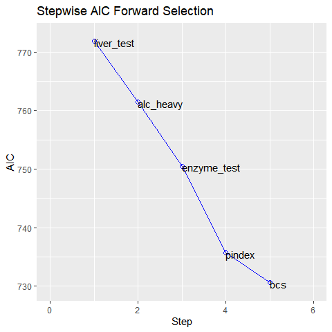

```r
model <- lm(y ~ ., data = surgical)
k <- ols_step_forward_aic(model)
plot(k)
```

### Detailed Output

```r
# stepwise aic forward regression
model <- lm(y ~ ., data = surgical)
ols_step_forward_aic(model, details = TRUE)
```

```
## Forward Selection Method
## ------------------------
##
## Candidate Terms:
##
## 1 . bcs
## 2 . pindex
## 3 . enzyme_test
## 4 . liver_test
## 5 . age
## 6 . gender
## 7 . alc_mod
## 8 . alc_heavy
##
##  Step 0: AIC = 802.606
##  y ~ 1
##
## --------------------------------------------------------------------------------
## Variable       DF      AIC        Sum Sq           RSS        R-Sq     Adj. R-Sq
## --------------------------------------------------------------------------------
## liver_test      1    771.875    3804272.477    4565248.060    0.455        0.444
## enzyme_test     1    782.629    2798309.881    5571210.656    0.334        0.322
## pindex          1    794.100    1479766.754    6889753.784    0.177        0.161
## alc_heavy       1    794.301    1454057.255    6915463.282    0.174        0.158
## bcs             1    797.697    1005151.658    7364368.879    0.120        0.103
## alc_mod         1    802.828     271062.330    8098458.207    0.032        0.014
## gender          1    802.956     251808.570    8117711.967    0.030        0.011
## age             1    803.834     118862.559    8250657.978    0.014       -0.005
## --------------------------------------------------------------------------------
##
##
## - liver_test
##
##
##  Step 1 : AIC = 771.8753
##  y ~ liver_test
##
## -------------------------------------------------------------------------------
## Variable       DF      AIC        Sum Sq          RSS        R-Sq     Adj. R-Sq
## -------------------------------------------------------------------------------
```

[output cut: 103 more lines]

```
## Residual      1833716.447        48      38202.426
## Total         8369520.537        53
## -----------------------------------------------------------------------
##
##                                       Parameter Estimates
## ------------------------------------------------------------------------------------------------
##       model         Beta    Std. Error    Std. Beta      t        Sig         lower       upper
## ------------------------------------------------------------------------------------------------
## (Intercept)    -1178.330       208.682                 -5.647    0.000    -1597.914    -758.746
##  liver_test       58.064        40.144        0.156     1.446    0.155      -22.652     138.779
##   alc_heavy      317.848        71.634        0.314     4.437    0.000      173.818     461.878
## enzyme_test        9.748         1.656        0.521     5.887    0.000        6.419      13.077
##      pindex        8.924         1.808        0.380     4.935    0.000        5.288      12.559
##         bcs       59.864        23.060        0.241     2.596    0.012       13.498     106.230
## ------------------------------------------------------------------------------------------------
```

```
##
##                              Selection Summary
## ----------------------------------------------------------------------------
## Variable         AIC        Sum Sq           RSS         R-Sq      Adj. R-Sq
## ----------------------------------------------------------------------------
## liver_test     771.875    3804272.477    4565248.060    0.45454      0.44405
## alc_heavy      761.439    4743349.776    3626170.761    0.56674      0.54975
## enzyme_test    750.509    5515514.136    2854006.401    0.65900      0.63854
## pindex         735.715    6278360.060    2091160.477    0.75015      0.72975
## bcs            730.620    6535804.090    1833716.447    0.78091      0.75808
## ----------------------------------------------------------------------------
```

## Stepwise AIC Backward Regression

Build regression model from a set of candidate predictor variables by removing predictors based on Akaike Information Criteria, in a stepwise manner until there is no variable left to remove any more. The model should include all the candidate predictor variables. If details is set to `TRUE`, each step is displayed.

### Variable Selection

```r
# stepwise aic backward regression
model <- lm(y ~ ., data = surgical)
k <- ols_step_backward_aic(model)
k
```

```
##
##
##                         Backward Elimination Summary
## ---------------------------------------------------------------------------
## Variable        AIC          RSS          Sum Sq        R-Sq      Adj. R-Sq
## ---------------------------------------------------------------------------
## Full Model    736.390    1825905.713    6543614.824    0.78184      0.74305
## alc_mod       734.407    1826477.828    6543042.709    0.78177      0.74856
## gender        732.494    1829435.617    6540084.920    0.78142      0.75351
## age           730.620    1833716.447    6535804.090    0.78091      0.75808
## ---------------------------------------------------------------------------
```

### Plot

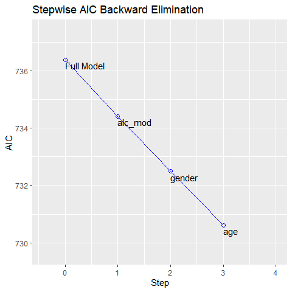

```r
model <- lm(y ~ ., data = surgical)
k <- ols_step_backward_aic(model)
plot(k)
```

### Detailed Output

```r
# stepwise aic backward regression
model <- lm(y ~ ., data = surgical)
ols_step_backward_aic(model, details = TRUE)
```

```
## Backward Elimination Method
## ---------------------------
##
## Candidate Terms:
##
## 1 . bcs
## 2 . pindex
## 3 . enzyme_test
## 4 . liver_test
## 5 . age
## 6 . gender
## 7 . alc_mod
## 8 . alc_heavy
##
##  Step 0: AIC = 736.3899
##  y ~ bcs + pindex + enzyme_test + liver_test + age + gender + alc_mod + alc_heavy
##
## --------------------------------------------------------------------------------
## Variable       DF      AIC        Sum Sq           RSS        R-Sq     Adj. R-Sq
## --------------------------------------------------------------------------------
## alc_mod        1     734.407        572.115    1826477.828    0.782        0.749
## gender         1     734.478       2990.338    1828896.051    0.781        0.748
## age            1     734.544       5231.108    1831136.821    0.781        0.748
## liver_test     1     735.878      51016.156    1876921.869    0.776        0.742
## bcs            1     741.677     263780.393    2089686.106    0.750        0.712
## alc_heavy      1     749.210     576636.222    2402541.935    0.713        0.669
## pindex         1     756.624     930187.311    2756093.024    0.671        0.621
## enzyme_test    1     763.557    1307756.930    3133662.644    0.626        0.569
## --------------------------------------------------------------------------------
##
##
## Variables Removed:
##
## - alc_mod
##
##
##   Step 1 : AIC = 734.4068
##  y ~ bcs + pindex + enzyme_test + liver_test + age + gender + alc_heavy
##
## --------------------------------------------------------------------------------
```

[output cut: 74 more lines]

```
## Residual      1833716.447        48      38202.426
## Total         8369520.537        53
## -----------------------------------------------------------------------
##
##                                       Parameter Estimates
## ------------------------------------------------------------------------------------------------
##       model         Beta    Std. Error    Std. Beta      t        Sig         lower       upper
## ------------------------------------------------------------------------------------------------
## (Intercept)    -1178.330       208.682                 -5.647    0.000    -1597.914    -758.746
##         bcs       59.864        23.060        0.241     2.596    0.012       13.498     106.230
##      pindex        8.924         1.808        0.380     4.935    0.000        5.288      12.559
## enzyme_test        9.748         1.656        0.521     5.887    0.000        6.419      13.077
##  liver_test       58.064        40.144        0.156     1.446    0.155      -22.652     138.779
##   alc_heavy      317.848        71.634        0.314     4.437    0.000      173.818     461.878
## ------------------------------------------------------------------------------------------------
```

```
##
##
##                         Backward Elimination Summary
## ---------------------------------------------------------------------------
## Variable        AIC          RSS          Sum Sq        R-Sq      Adj. R-Sq
## ---------------------------------------------------------------------------
## Full Model    736.390    1825905.713    6543614.824    0.78184      0.74305
## alc_mod       734.407    1826477.828    6543042.709    0.78177      0.74856
## gender        732.494    1829435.617    6540084.920    0.78142      0.75351
## age           730.620    1833716.447    6535804.090    0.78091      0.75808
## ---------------------------------------------------------------------------
```

## Stepwise AIC Regression

Build regression model from a set of candidate predictor variables by entering and removing predictors based on Akaike Information Criteria, in a stepwise manner until there is no variable left to enter or remove any more. The model should include all the candidate predictor variables. If details is set to `TRUE`, each step is displayed.

### Variable Selection

```r
# stepwise aic regression
model <- lm(y ~ ., data = surgical)
ols_step_both_aic(model)
```

```
##
##
##                                      Stepwise Summary
## ----------------------------------------------------------------------------------------
## Variable        Method       AIC          RSS          Sum Sq        R-Sq      Adj. R-Sq
## ----------------------------------------------------------------------------------------
## liver_test     addition    771.875    4565248.060    3804272.477    0.45454      0.44405
## alc_heavy      addition    761.439    3626170.761    4743349.776    0.56674      0.54975
## enzyme_test    addition    750.509    2854006.401    5515514.136    0.65900      0.63854
## pindex         addition    735.715    2091160.477    6278360.060    0.75015      0.72975
## bcs            addition    730.620    1833716.447    6535804.090    0.78091      0.75808
## ----------------------------------------------------------------------------------------
```

### Plot

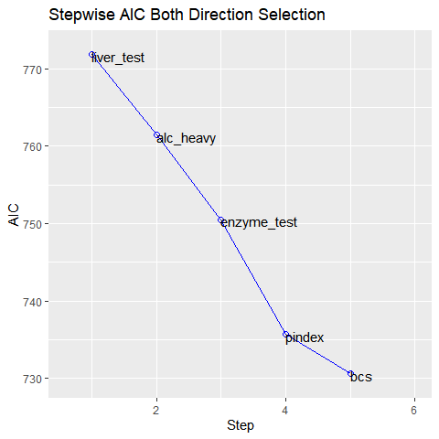

```r
model <- lm(y ~ ., data = surgical)
k <- ols_step_both_aic(model)
plot(k)
```

### Detailed Output

```r
# stepwise aic regression
model <- lm(y ~ ., data = surgical)
ols_step_both_aic(model, details = TRUE)
```

```
## Stepwise Selection Method
## -------------------------
##
## Candidate Terms:
##
## 1 . bcs
## 2 . pindex
## 3 . enzyme_test
## 4 . liver_test
## 5 . age
## 6 . gender
## 7 . alc_mod
## 8 . alc_heavy
##
##  Step 0: AIC = 802.606
##  y ~ 1
##
##
## Variables Entered/Removed:
##
##                                Enter New Variables
## --------------------------------------------------------------------------------
## Variable       DF      AIC        Sum Sq           RSS        R-Sq     Adj. R-Sq
## --------------------------------------------------------------------------------
## liver_test      1    771.875    3804272.477    4565248.060    0.455        0.444
## enzyme_test     1    782.629    2798309.881    5571210.656    0.334        0.322
## pindex          1    794.100    1479766.754    6889753.784    0.177        0.161
## alc_heavy       1    794.301    1454057.255    6915463.282    0.174        0.158
## bcs             1    797.697    1005151.658    7364368.879    0.120        0.103
## alc_mod         1    802.828     271062.330    8098458.207    0.032        0.014
## gender          1    802.956     251808.570    8117711.967    0.030        0.011
## age             1    803.834     118862.559    8250657.978    0.014       -0.005
## --------------------------------------------------------------------------------
##
## - liver_test added
##
##
##  Step 1 : AIC = 771.8753
##  y ~ liver_test
##
```

[output cut: 140 more lines]

```
## Residual      1833716.447        48      38202.426
## Total         8369520.537        53
## -----------------------------------------------------------------------
##
##                                       Parameter Estimates
## ------------------------------------------------------------------------------------------------
##       model         Beta    Std. Error    Std. Beta      t        Sig         lower       upper
## ------------------------------------------------------------------------------------------------
## (Intercept)    -1178.330       208.682                 -5.647    0.000    -1597.914    -758.746
##  liver_test       58.064        40.144        0.156     1.446    0.155      -22.652     138.779
##   alc_heavy      317.848        71.634        0.314     4.437    0.000      173.818     461.878
## enzyme_test        9.748         1.656        0.521     5.887    0.000        6.419      13.077
##      pindex        8.924         1.808        0.380     4.935    0.000        5.288      12.559
##         bcs       59.864        23.060        0.241     2.596    0.012       13.498     106.230
## ------------------------------------------------------------------------------------------------
```

```
##
##
##                                      Stepwise Summary
## ----------------------------------------------------------------------------------------
## Variable        Method       AIC          RSS          Sum Sq        R-Sq      Adj. R-Sq
## ----------------------------------------------------------------------------------------
## liver_test     addition    771.875    4565248.060    3804272.477    0.45454      0.44405
## alc_heavy      addition    761.439    3626170.761    4743349.776    0.56674      0.54975
## enzyme_test    addition    750.509    2854006.401    5515514.136    0.65900      0.63854
## pindex         addition    735.715    2091160.477    6278360.060    0.75015      0.72975
## bcs            addition    730.620    1833716.447    6535804.090    0.78091      0.75808
## ----------------------------------------------------------------------------------------
```